# Data 606-Lab 1: Intro to R

### Exercise 3

It is difficult to discern a obvious trend(s) in the proportion of boys born over time. This owes, in part, to high inter-annual variation.

Note: I don’t believe we have established that baptism counts accurately track male/female births year-to-year.

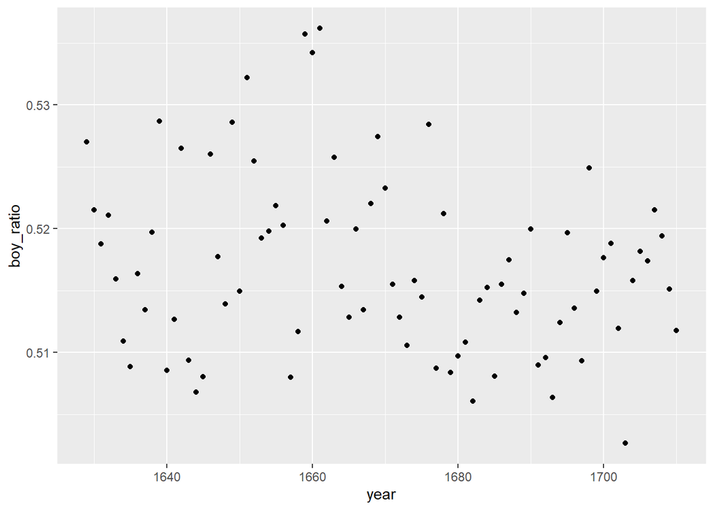

```r
#create scatterplot for the ratio of boy baptism counts (to total) each year

ggplot(data=arbuthnot, aes(x=year, y=boy_ratio))+geom_point()
```

```r
# evaluate number of births of boys relative to girls each year (see also: Exercise 2)

arbuthnot<- arbuthnot%>%mutate(more_boys=boys>girls)

# find the min and max count for boys

arbuthnot%>%summarize(min=min(boys), max=max(boys))
```

```
## # A tibble: 1 x 2
##     min   max
##   <int> <int>
## 1  2890  8426
```

### Exercise 4

Included Years: 1940-202

DF dimensions: 63 rows, 3 cols

Column names: year, boys, girls

```r
#preview data set

present
```

```
## # A tibble: 63 x 3
##     year    boys   girls
##    <dbl>   <dbl>   <dbl>
##  1  1940 1211684 1148715
##  2  1941 1289734 1223693
##  3  1942 1444365 1364631
##  4  1943 1508959 1427901
##  5  1944 1435301 1359499
##  6  1945 1404587 1330869
##  7  1946 1691220 1597452
##  8  1947 1899876 1800064
##  9  1948 1813852 1721216
## 10  1949 1826352 1733177
## # ... with 53 more rows
```

```r
# return years column

present$year
```

```
##  [1] 1940 1941 1942 1943 1944 1945 1946 1947 1948 1949 1950 1951 1952 1953 1954
## [16] 1955 1956 1957 1958 1959 1960 1961 1962 1963 1964 1965 1966 1967 1968 1969
## [31] 1970 1971 1972 1973 1974 1975 1976 1977 1978 1979 1980 1981 1982 1983 1984
## [46] 1985 1986 1987 1988 1989 1990 1991 1992 1993 1994 1995 1996 1997 1998 1999
## [61] 2000 2001 2002
```

```r
# return dataframe dimensions

dim(present)
```

```
## [1] 63  3
```

```r
# return column names

names(present)
```

```
## [1] "year"  "boys"  "girls"
```

### Exercise 5

Annual birth counts in the ‘Present’ data set are several orders of magnitude greater than annual baptism counts included in the Arbuthnot data set.

In the ‘Present’ data set, total birth counts increased by 1661327 between 1940 & 2002. Interim trends in birth counts were equivalent for boys and girls.

There was notable, but temporary, decline in birth rates that culminated in the mid-70s. I speculate that this may related to economic stresses related to the oil crisis, etc.

```r
# return max and min birth counts for boys and girls over period of record

present%>%pivot_longer(cols=c(boys, girls), names_to = 'gender', values_to ='value')%>%group_by(gender)%>%summarize(min=min(value), max=max(value))
```

```
## # A tibble: 2 x 3
##   gender     min     max
## * <chr>    <dbl>   <dbl>
## 1 boys   1211684 2186274
## 2 girls  1148715 2082052
```

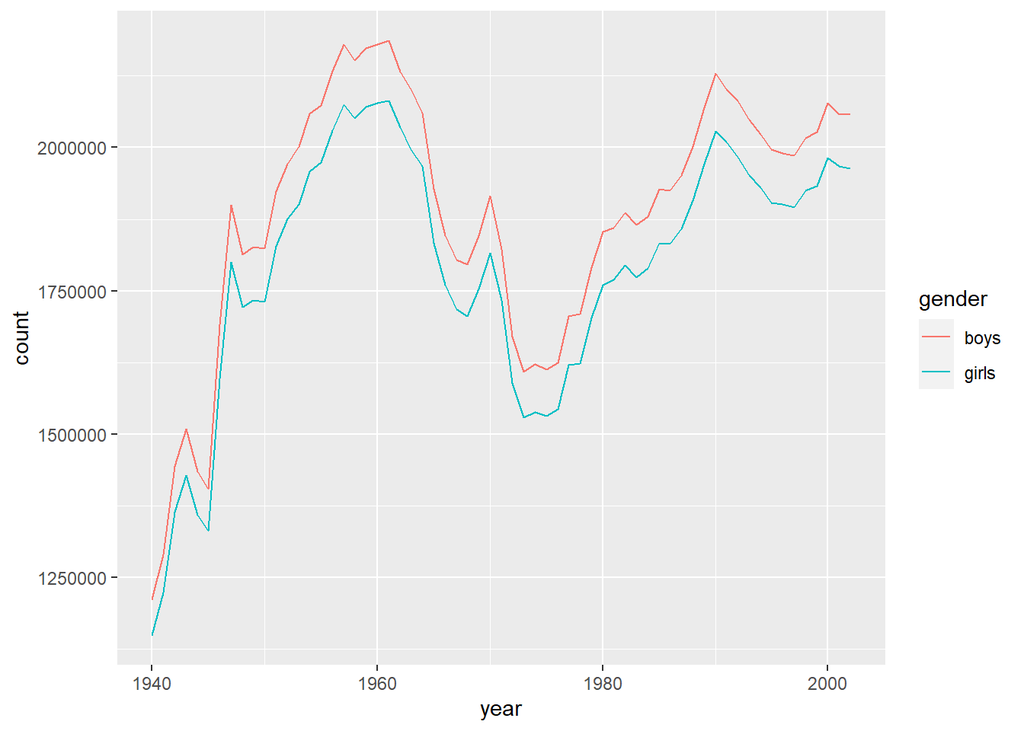

```r
# plot birth count of boys vs girls by year

plot_gender <- present%>%pivot_longer(cols=c(boys, girls), names_to = 'gender', values_to ='count')

ggplot(plot_gender, aes(x=year, y=count, color=gender)) +geom_line()
```

```r
# create new column for total birth counts, plot counts by year, return difference in total count between 1940 & 2002

present <- present%>%mutate(total=girls+boys)

plot_total <- ggplot(data=present, aes(x=year, y=total))+geom_line()

present$total%>%last()-present$total%>%first()
```

```
## [1] 1661327
```

### Exercise 6

Arbuthnot’s observation that boys are born in greater proportion than girls in the U.S. does hold true in the ‘Present’ dataset.

The offset in boy and girl birth counts (relative to total) is similar in magnitude across data sets.

However in the ‘Present’ data set, the proportion of male births (relative to total) decreases over time, while the opposite is true for females.

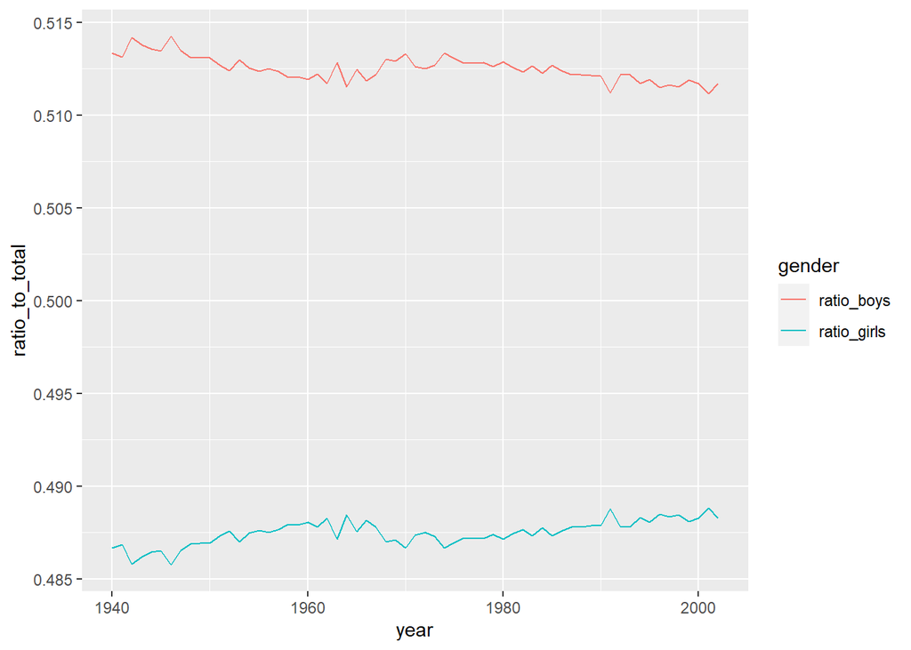

```r
# create new column with ratio of boys:total births by year, repeat  for girls, plot ratios for each gender.

present<- present%>%mutate(ratio_boys=boys/total)%>%mutate(ratio_girls=girls/total)

plot_ratio <- present%>%pivot_longer(cols=c(ratio_boys, ratio_girls), names_to = 'gender', values_to ='ratio_to_total')

ggplot(plot_ratio, aes(x=year, y=ratio_to_total, color=gender))+geom_line()
```

### Exercise 7

The greatest total number of births in the U.S. (for the period of record) occurred in 1961.

```r
present %>%arrange(desc(total))
```

```
## # A tibble: 63 x 6
##     year    boys   girls   total ratio_boys ratio_girls
##    <dbl>   <dbl>   <dbl>   <dbl>      <dbl>       <dbl>
##  1  1961 2186274 2082052 4268326      0.512       0.488
##  2  1960 2179708 2078142 4257850      0.512       0.488
##  3  1957 2179960 2074824 4254784      0.512       0.488
##  4  1959 2173638 2071158 4244796      0.512       0.488
##  5  1958 2152546 2051266 4203812      0.512       0.488
##  6  1962 2132466 2034896 4167362      0.512       0.488
##  7  1956 2133588 2029502 4163090      0.513       0.487
##  8  1990 2129495 2028717 4158212      0.512       0.488
##  9  1991 2101518 2009389 4110907      0.511       0.489
## 10  1963 2101632 1996388 4098020      0.513       0.487
## # ... with 53 more rows
```